# Summarization in Bioconductor exercises

Tom Carroll

## Summarizing data

In these exercises we will review some of the functionality for summarizing counts and signal across genomes and within regions.

The example data can be found in the data directory

**Data/heart.bodyMap.bam** **Data/liver.bodyMap.bam**

1. Sort and index both the heart.bodyMap.bam and liver.bodyMap.bam files.

```
## [1] "Liver.bam"
```

```
## [1] "Heart.bam"
```

```
##       Liver.bam
## "Liver.bam.bai"
```

```
##       Heart.bam
## "Heart.bam.bai"
```

2. Calculate the coverage from the sorted, indexed BAM files normalised to the total mapped reads per sample.
3. Plot the coverage for Heart and Liver samples over region Chr12 98,986,183-98,998,558 using ggplot2

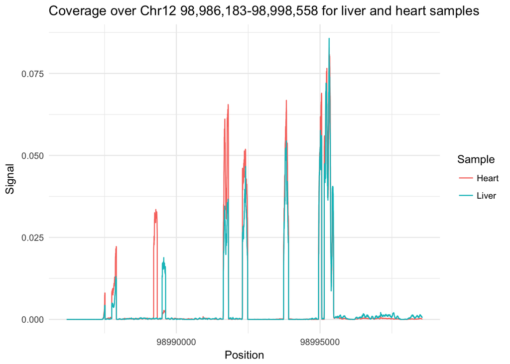

4. Using the normalised coverage for heart and liver samples, calculate the sum coverage within TSS (+500bp/-500bp) of the TMPO, SLC25A3 and IKBIP genes. Create a barplot of the sum coverage for each gene using ggplot2.

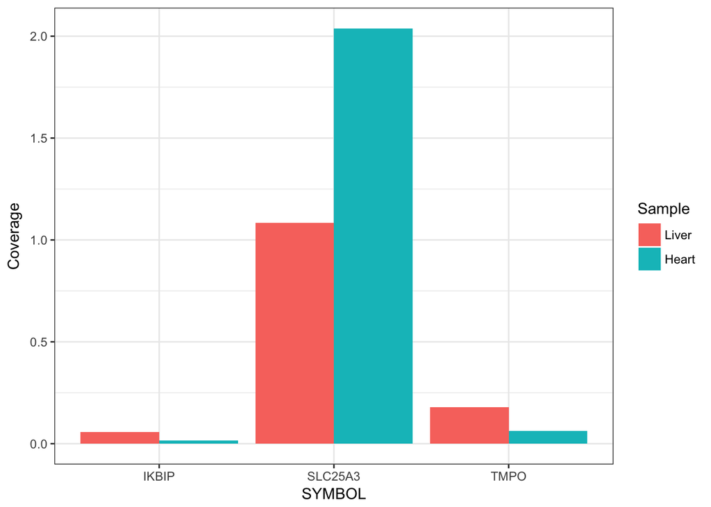

5. Using the summarizeOverlaps() function, count reads from Heart and liver samples in the TMPO, SLC25A3 and IKBIP genes. Normalise reads to total number of mapped reads in the sample per million mapped reads and plot the mean counts per gene versus the log2 fold difference between heart and liver samples.

```
## [1] "Liver.bam"
```

```
## [1] "Heart.bam"
```

```
##       Liver.bam
## "Liver.bam.bai"
```

```
##       Heart.bam
## "Heart.bam.bai"
```

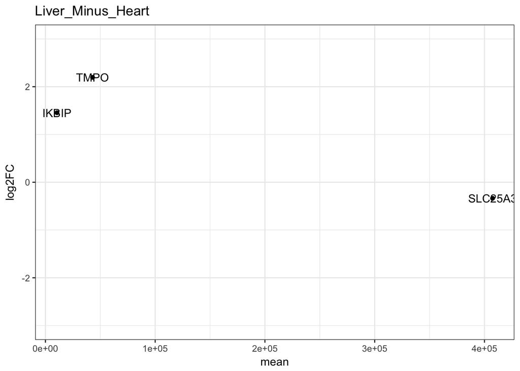